# Tema 01 - Informes reproducibles con Quarto

Análisis de Datos Multivariantes aplicado al Marketing - Curso 2026/27  
Universidad de Alicante

Pedro Albarrán

Dpto. de Fundamentos del Análisis Económico. Universidad de Alicante

Luis Pérez

## El sistema de publicaciones [Quarto](https://quarto.org/)

- Orientado al análisis de datos **reproducible**: combina código, resultados y comentarios
- Útil como cuaderno de trabajo del código y para **comunicar** resultados en un documento final para tomar decisiones

[figure not shown]

- Instalar Quarto para vuestro sistema operativo desde [aquí](https://quarto.org/docs/get-started/)
  - la web pide después elegir un editor: **en Positron no hay que hacer nada más**, ya trae la extensión de Quarto incorporada
- La [guía](https://quarto.org/docs/guide/) y [referencia](https://quarto.org/docs/reference/) completa de Quarto están en su Web
- Un documento de Quarto se renderiza, procesando cada componente (código, resultado de ejecutarlo y texto) para producir documentos en varios formatos: html, PDF, Word, presentaciones, etc.

## Documentos de Quarto: Crear y Guardar

- Se trabaja dentro de la **carpeta del proyecto** (*File > Open Folder*); el documento se crea en *File > New File… > Quarto Document* y se guarda **con extensión `.qmd`** (`Ctrl+S`)
- Se renderiza con el botón **Preview** (`Ctrl+Shift+K`)
- El resultado sale en el **visor** de la derecha y, a la vez, se crea el fichero en la carpeta del proyecto
- Para verlo **como lo verá quien lo reciba**, abridlo con doble clic desde el **explorador de archivos del sistema**: el `.html` se abre en el navegador, y un `.pdf` o `.docx` en su programa

[figure not shown]

**1** *Preview* · **2** guardar · **3** el fichero creado · **4** el visor

## Documentos de Quarto: formato de salida

- El renderizado crea un archivo en el mismo directorio donde está el archivo de Quarto .qmd
- En el caso de HTML, se crea tanto un archivo con extensión .html como un subdirectorio del mismo nombre con componentes necesarios (ej., imágenes, css)
  - solo podemos visualizar correctamente el archivo .html en cualquier navegador si copiamos a otro lugar tanto el .html como el subdirectorio
- Los formatos de salida posibles son **html** (el que viene por defecto), **Word** y **PDF**. Más adelante veremos dónde se elige
- Para **PDF** hay dos caminos:
  - por **LaTeX**, que hay que instalar una vez (en la pestaña **Terminal**, a la derecha de la consola): `quarto install tool tinytex`
  - por **typst**, que **no necesita instalar nada**: Quarto ya lo trae incorporado, y es mucho más rápido
- Para este curso, con html basta. Word y typst tampoco necesitan instalar nada

## Elegir el formato desde **Preview**

- **Preview** es un **desplegable**: su flecha abre *Preview Format…*, que lista los formatos y renderiza al que se elija, sin tocar la cabecera
- Aparece el que **ya lleva el documento** (*Declared Formats*) y los demás (*Other Formats*): PDF con typst, PDF con LaTeX y Word

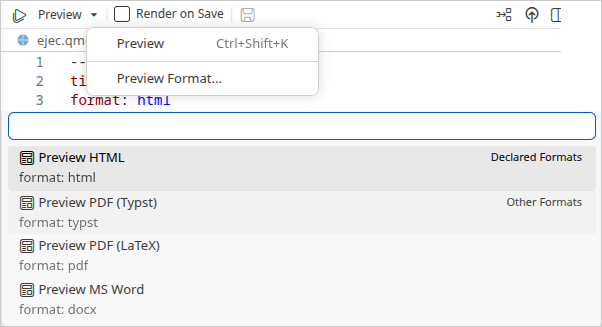

**Nota**

**Ahora el ejercicio: apartado a), puntos i, ii, iv y v**: crear la carpeta y el documento, guardarlo con su nombre y renderizarlo.

## Documentos de Quarto: Texto con Markdown

- Los componentes de texto están escritos en Markdown: un conjunto ligero de convenciones para archivos de texto sin formato. Por ejemplo,
  - todo lo escrito entre dos * como `**Hola**` se renderiza en negritas
  - se utiliza # para indicar encabezados de secciones
- Una descripción completa, en [la web de Quarto](https://quarto.org/docs/authoring/markdown-basics.html) (Markdown Basics); también es útil este [libro online](https://bookdown.org/yihui/rmarkdown/).
- Positron incorpora un **editor visual** de documentos de Quarto, similar a un procesador de texto
  - un ventaja del modo no visual es el número de línea, para errores

## Editor Visual de Quarto en Positron

- Un `.qmd` se edita de dos formas: el **texto** tal cual (modo *source*), como hasta ahora, o en **modo visual**, ya con su formato
- **Edit in Visual Mode** está en el menú `...` del editor, arriba a la derecha, y en el **menú contextual** que sale al pulsar el botón derecho sobre el documento
- Para volver, la misma entrada dice **Edit in Source Mode**

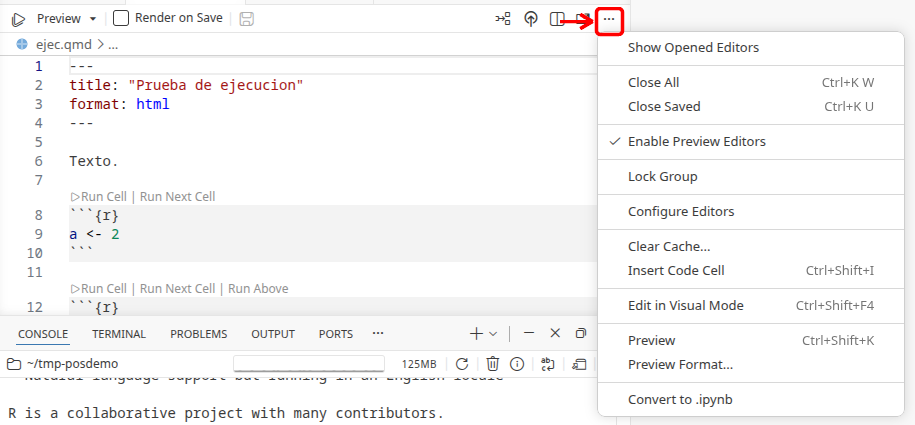

Atajo: `Ctrl+Shift+F4`. También en la paleta de comandos (`Ctrl+Shift+P`)

## Formato en la cabecera: el bloque `YAML`

- Al **principio del documento**, entre dos líneas con `---`, se pueden especificar varias opciones del documento: título, autor, fecha, formato de salida
  - en **modo visual** se inserta desde *Insert > YAML Metadata…*, sin escribir los `---`
- Los formatos de salida son `html`, `pdf`, `docx` (y otros en *Quarto Presentations*), y también opciones globales, algunas propias de cada formato ([referencia](https://quarto.org/docs/reference/formats/html.html))

  ```
    ---
    title: "Título"
    author: Autor
    date: 15-octubre-2025
    format:
      html:
        toc: true              # índice
        number-sections: true  # secciones numeradas
        embed-resources: true  # archivo html autocontenido
        theme: united          # más temas: https://bootswatch.com/3/
    ---
  ```

**Y ahora el resto del apartado a): iii, vi y vii.**

## Fragmentos o celdas de código

- El documento lleva **código de R que Quarto ejecuta al renderizar**; hay dos formas, según dónde deba salir el resultado
- **Código en línea**: un valor **dentro de una frase** (“la media es 20.09”); icono `</>` de la barra, o *Insert > Any…* (`Ctrl+/`) y escribir `inline`
- Una **celda**: bloque de código aparte, el resultado sale **debajo** (*Insert > Executable Cell > R*)

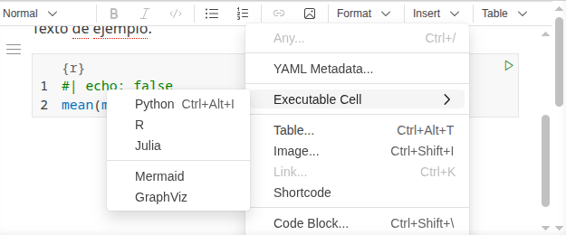

- En **modo source** ambas se escriben a mano: el código en línea, con `` `r ` `` y dentro el código; la celda, entre `` ```{r} `` y `` ``` ``

## Opciones de una celda

- Van **dentro** de la celda, en sus primeras líneas, precedidas de `#|` (almohadilla y **barra vertical**; con `#` a secas es un comentario y la opción NO se aplica)

````markdown
```{r}
#| echo: false
mean(mtcars$mpg)
```
````

- `echo` (¿se **ve** el código?) y `eval` (¿se **ejecuta**?) son independientes:

| `echo` | `eval` | se ve el código | se ejecuta | se ve el resultado |
| --- | --- | --- | --- | --- |
| `true` | `true` | sí | sí | sí |
| `false` | `true` | **no** | sí | sí |
| `true` | `false` | sí | **no** | no |

## Otras opciones de celda

- `output: false` oculta **solo el resultado**; `include: false` no muestra nada, pero **sí ejecuta**
- `message`, `warning` y `error`: si se muestra lo que R va contando por el camino
- `label`: una etiqueta para identificar la celda
- `code-fold: true` oculta el código pero da opción a mostrarlo
- *Cómo* mostrar resultados de texto y numéricos:
  - `results: hide` (no mostrar)
  - `results: hold` (mostrar todo, no el resultado de cada línea)

## La primera celda del documento

- Todo documento empieza con una celda que **prepara el entorno**: ahí se declaran las **bibliotecas** que se van a usar y se ejecuta lo que necesiten las demás celdas
- Lleva `include: false`: se ejecuta, pero no se ve ni ella ni sus mensajes

````markdown
```{r}
#| include: false
library(AER)
```
````

- Hace falta porque al renderizar se abre una **sesión de R nueva y vacía**: el documento no ve nada de lo que tengáis en la consola y tiene que cargar lo suyo
- Cogedlo como costumbre: primera celda, entorno preparado. Vale para el resto del curso

**Nota**

**Ahora el ejercicio: apartado b)**, empezando por esa primera celda.

## Opciones de presentación

- `fig-cap` y `tbl-cap` para los títulos de las figuras y tablas
- *Cómo* mostrar los gráficos: `fig-show`
  - `hide` y `hold` son como en `results`
  - `asis` muestra el gráfico como se generó
  - `animate` concatena varios gráficos en una animación
- `fig-width` y `fig-height`: dimensiones (reales, en pulgadas) de una figura
- `out-width` y `out-height`: ídem en el documento de salida (% de las reales)
- Lista completa de opciones [aquí](https://quarto.org/docs/reference/cells/cells-knitr.html)

## Opciones para figuras

- `fig-align`: mostrar la figura centrada o alineada a derecha o izquierda
- `layout-ncol`: en cuántas columnas se componen los resultados

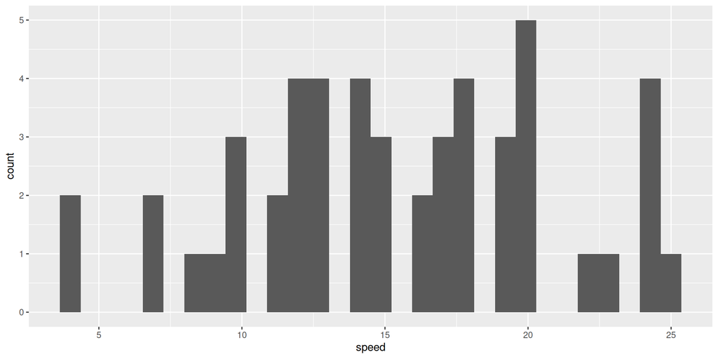

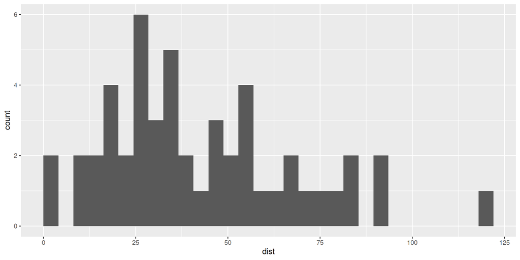

```r
library(ggplot2)
ggplot(cars) + geom_histogram(aes(x = speed))
ggplot(cars) + geom_histogram(aes(x = dist))
```

**Nota**

**Ahora el ejercicio: apartado c)**, los dos gráficos uno al lado del otro con `layout-ncol`.

## Opciones globales para todas las celdas

- En la cabecera, especificamos opciones **por defecto** para las celdas de código
  - p.e., de ejecución como `echo`, `eval`, etc. en `execute` (ver [aquí](https://quarto.org/docs/reference/formats/html.html#execution) y [aquí](https://quarto.org/docs/computations/r.html))

    ```
    ---
    execute:
      echo: false
      warning: false
    ---
    ```

  - También otras opciones que ya hemos visto ([aquí listado completo para `html`](https://quarto.org/docs/reference/formats/html.html))

    ```
    ---
    format:
      html:
        code-fold: true
        cap-location: bottom
        fig-align: center
        df-print: paged      # cómo visualizar tablas
    ---
    ```

## Ejecución de código en un documento .qmd

- Renderizar un .qmd crea un *espacio de trabajo* para ejecutar el código **distinto** del de nuestra consola (diferentes objetos, bibliotecas, etc.)
  - si no estamos en la carpeta correcta, el directorio de trabajo puede ser diferente
- Comprobamos los resultados del código del .qmd ejecutándolo **sin renderizar**: línea a línea (`Ctrl + Enter`), o con los enlaces que aparecen **sobre cada celda**: *Run Cell* (esa celda), *Run Above* (todas las anteriores) y *Run Next Cell*
  - así, el código pasa a la consola y *sí* forma parte del espacio de la sesión actual
  - nos aseguramos de que no hay errores (ej., objetos previos no definidos)
- La **celda inicial** que ya hemos visto sirve también para esto: como lleva `include: false`, se puede poner en ella
  - `rm(list = ls())`: al ejecutar todas las celdas previas, empezamos con una sesión sin objetos previos, sólo con lo del .qmd
  - Todas las **bibliotecas** que se usen en varias celdas (con `library()`, como en el Tema 00)

## Mejorar la salida de tablas

- La salida “en crudo” de R es correcta y poco presentable. `knitr::kable()` la convierte en una tabla con formato:

```r
knitr::kable(head(mtcars[, 1:5]))
```

[output not shown]

- `kableExtra` añade estilos, anchos, cabeceras agrupadas… ([guía](https://cran.r-project.org/web/packages/kableExtra/vignettes/awesome_table_in_html.html))
- Primero que el **número** sea el correcto; después, que la tabla se vea bien

**Nota**

**Ahora el ejercicio: apartados d) y e)**: mostrar `mtcars` con `kbl()` y comparar con la salida cruda, y luego las opciones de cabecera (`df-print: paged`, `code-fold`, tema).

## Comentarios finales

- **Dashboards** (tableros): son presentaciones visuales e **interactivas** de los resultados claves de un análisis que permiten una comunicación más efectiva
  - Quarto permite crear [*dashboards*](https://quarto.org/docs/interactive/) con tablas, gráficos y otros elementos
  - Ejemplos de sus capacidades usando el paquete [shiny](https://shiny.rstudio.com/gallery/), [shinydashboards](https://rstudio.github.io/shinydashboard/) o [flexdashboard](https://pkgs.rstudio.com/flexdashboard/articles/examples.html)
- **Jupyter Notebook**: son otra forma de combinar texto, código y resultados en un documento. Desarrollados para `Python`, admiten varios lenguajes de programación (como Quarto)
  - se crean, visualizan y ejecutan en navegadores web, pero son fácilmente modificables, [localmente](https://jupyter.org/install) u online en [**JupyterLab**](https://jupyter.org/try) o con [Google Colab](https://colab.research.google.com/)
  - Quarto renderiza libros de Jupyter, creados en .qmd o en su propio formato
- Muchas herramientas están preparadas para `Python` y `R` porque se usan a menudo indistintamente o combinados